# Homework 9

Iman Malik

2025-04-21

UT EID: im22856

GitHub repo: https://github.com/imanmalik16/SDS-315.git

## Problem 1: Manufacturing flaws in circuit boards

### a)

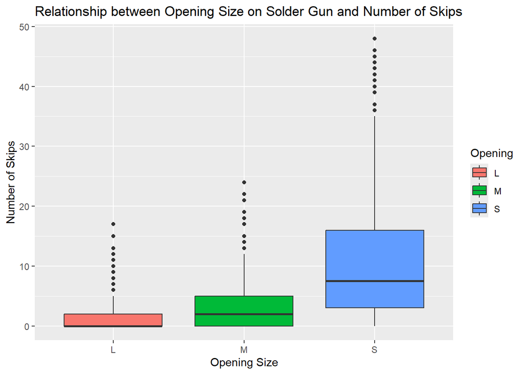

The grouped boxplot shows the distribution of solder skips by opening size (Small, Medium, Large) of the solder gun. As depicted in the plot, it seems smaller openings tend to have a higher number of skips, while larger openings typically have fewer skips. This suggests a negative relationship between solder skips and opening size; as opening size gets bigger, the number of skips typically decreases.

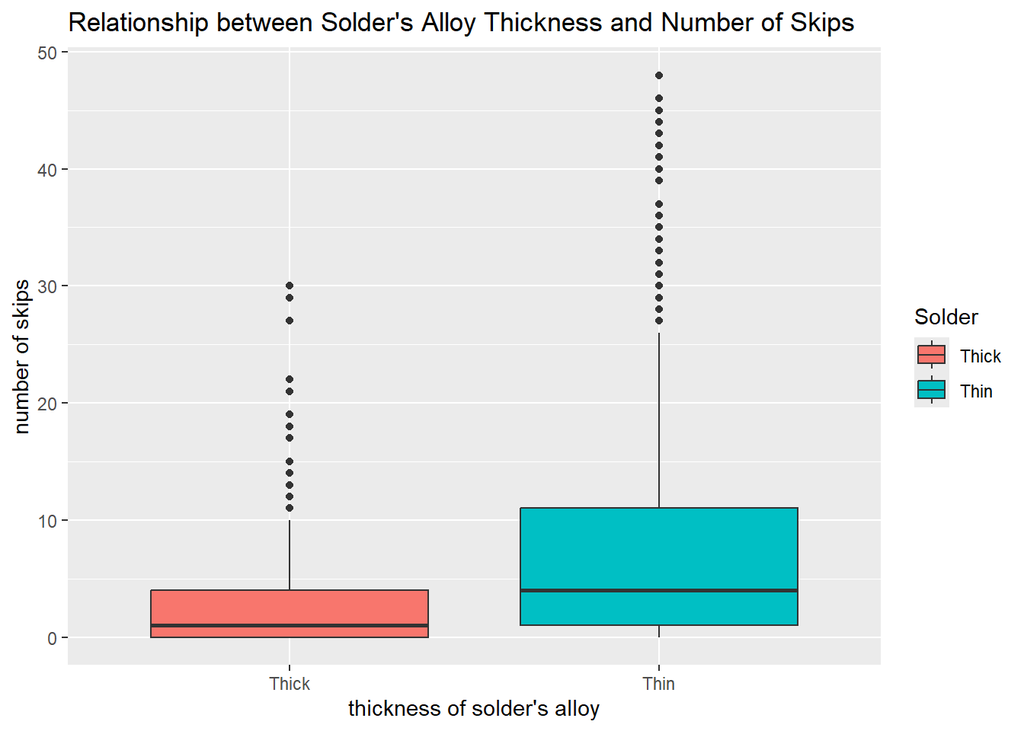

The grouped boxplot shows the distribution of solder skips by the alloy thickness (Thick, Thin) of the solder gun. As depicted in the plot, it seems thinner alloy tends to result in a higher number of skips, while thicker alloy typically have fewer skips. This suggests a negative relationship between solder skips and alloy thickness; as alloy gets thicker, the number of skips typically decreases.

### b)

```
## # A tibble: 6 × 4
##   term                  estimate lower_ci upper_ci
##   <chr>                    <dbl>    <dbl>    <dbl>
## 1 intercept                0.393   -0.628     1.42
## 2 Opening: M               2.41     0.962     3.85
## 3 Opening: S               5.13     3.68      6.57
## 4 Solder: Thin             2.28     0.836     3.72
## 5 Opening: M:SolderThin   -0.74    -2.78      1.30
## 6 Opening: S:SolderThin    9.65     7.61     11.7
```

### c)

The baseline rate of solder skips when the opening size is large and the solder thickness is thick is about 0.393. When the opening size is medium and the solder thickness is thick, the average skip rate is increased by about 2.407. When the opening size is small and the solder thickness is thick, the average skip rate is increased by about 5.127. When the opening size is large and the solder thickness is thin, the skip rate is increased by about 2.280. When the opening size is medium and the solder thickness is thin, the skip rate is decreased by about 0.740. When the opening size is small and the solder thickness is thin, the skip rate is increased by about 9.653.

### d)

I would recommend a large opening size with thick alloy thickness to AT&T. According to the model, this combination is correlated to the lowest number of skips, and therefore it seems most efficient to reduce the number of solder skips on the circuit board.

## Problem 2: Grocery store prices

### a)

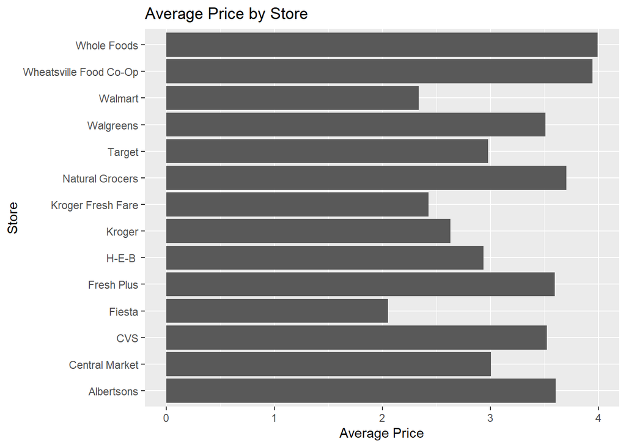

### b)

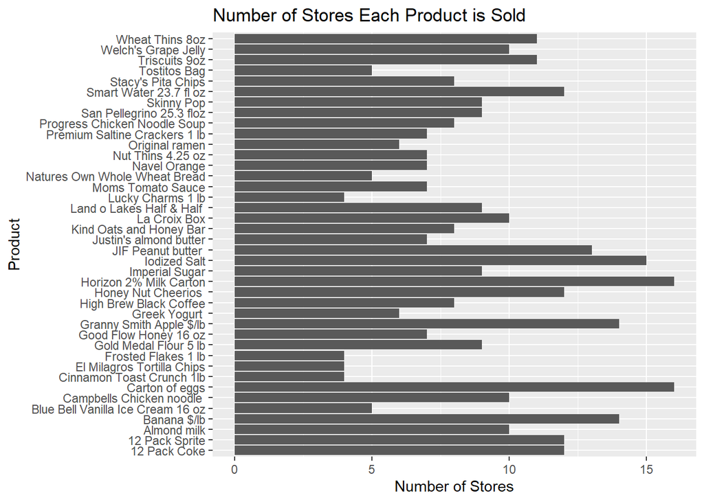

The bar graph shows how many different stores sold each product listed in the data set. Products like milk and eggs appear in all 16 stores, while other more niche items are available in a fewer number of stores. The graph illustrates the importance of considering what products are sold at various stores when comparing average prices across stores.

### c)

Compared with ordinary grocery stores (like Albertsons, HEB, or Krogers), convenience stores charge somewhere between 0.41 and 0.92 dollars more for the same product, with 95% confidence.

### d)

The two stores that seem to charge the lowest prices when comparing the same product are Walmart (95% CI: -1.45 to -0.53) and Kroger Fresh Fare (95% CI: -1.36 to -0.44). The two stores that seem to charge the highest prices when comparing the same product are Whole Foods (95% CI: 0.02 to 0.71) and Wheatsville Food Co-Op (95% CI: -0.06 to 0.64).

### e)

According to the fitted model, Central Market charges about 0.57 dollars less for the same product than our baseline store, which in this case is Albertsons. HEB charges about 0.65 dollars less for the same product than our baseline store. Therefore, it seems that Central Market charges about 0.08 dollars more than HEB for the same product, but this is not a very practically significant difference in price for most people.

### f)

The sign of the Income10K coefficient is negative, indicating a negative slope. This suggests a negative relationship between prices and income, so consumers in poorer ZIP codes seem to pay more for the same product, on average. A one standard deviation increase in the income of a ZIP code seems to be associated with a -0.03 standard deviation change in the price that consumers in that ZIP code expect to pay for the same product.

## Problem 3: redlining

1. True; The regression table for FAIR policies on the minority percentage shows that the minority coefficient is 0.014. Also from the table, we can say with 95% confidence that the true change in the number of FAIR policies as minority percentage goes up is between 0.009 and 0.018. Because this interval does not contain 0, the result is statistically significant so we have convincing evidence that ZIP codes with a higher percentage of minority residents tend to have more FAIR policies per 100 housing units. The R^2 value is 0.516, indicating that a majority of the variation in FAIR policies can be attributed to minority percentage. Additionally, Figure A1 shows a positive linear correlation between percentage minority residents and FAIR policies, suggesting that as the percentage of minority residents increases, the number of FAIR policies also typically increases per 100 housing units.
2. Undecidable; Figure B1 depicts a mildy positive correlation between the age of the housing stock and the minority percentage. Although the age coefficient estimate is 0.398, the 95% confidence interval (-0.116 to 0.912) contains zero, so the result is not statistically significant. Additionally, the R^2 value is 0.06, which is extremely low and suggests that barely any of the random variation in minority percentage can be attributed to the age of the housing stock. There is also no model that assesses an interaction effect between minority percentage and age, which would be helpful to determine the validity of the statement.
3. False; The 95% confidence interval for the interaction effect between minority and low fire risk contains zero and the p-value is 0.839, which suggests no evidence of a statistically significant effect on FAIR policies by fire risk (no statistically significant interaction). Additionally, the slopes of the linear trend line on Figure C1 look roughly equal.
4. False; From Model D1, we can see that the minority coefficient estimate is 0.014, with a 95% confidence interval from 0.009 to 0.018. Because this interval does not contain zero, the result is statistically significant. Now looking at Model D2 which controls for income as well, the minority coefficient estimate drops very slightly to 0.01, with a 95% confidence interval from 0.004 to 0.015. This interval also does not contain zero, so the result remains statistically significant. Therefore, although income seems to have a slight effect, it does not “explain away” all the association between minority percentage and FAIR policy uptake.
5. True; Model E, which controls for minority percentage as well as income, fire risk, and housing age, estimates the minority coefficient to be 0.008, with a 95% confidence interval between 0.003 to 0.014. Because this interval does not contain zero, the result is statistically significant, so we have convincing evidence that minority percentage and number of FAIR policies are still associated at the ZIP code level, even after controlling for income, fire risk, and housing age. Additionally, the R^2 value for Model E is 0.662, indicating that a majority of the variation in FAIR policies can be attributed to minority percentage while still accounting for income, fire risk, and housing age.